None

# Интернет-магазин «Стримчик»

## Общая информация

Интернет-магазине «Стримчик» продаёт по всему миру компьютерные игры. Из открытых источников получены данные о продажах игр, оценки пользователей и экспертов, жанры и платформы. Данные предоставленны до 2016 г, однако за последний год данные могут быть неполными.

**Цель**: выявить определяющие успешность игры закономерности для определения потенциально популярного продукта и планирования рекламных кампаний на 2017 г.

**Задачи**:

1. Предобработка данных:
   - загрузка данных;
   - переименование столбцов;
   - исследование и обработка пропусков;
   - исследование и обработка явных и неявных дубликаты;
   - исследование и приведение в соответствие типов данных.
2. Исследовательский анализ:
   - определение количества игр, выпускавшихся в разные годы;
   - исследование изменения продаж по платформам;
   - определение наиболее прибыльных платформ;
   - определение влияения отзывов пользователей и критиков на продажи;
   - исследование распределения игр по жанрам.
3. Составление портрета пользователя регионов:
   - определение ТОП-5 популярных платформ;
   - определение ТОП-5 популярных жанров;
   - оценка влияния рейтинга ESRB на продажи в регионах.
4. Проверка гипотез:
   - о равенстве средних пользовательских рейтингов платформ Xbox One и PC;
   - о равенстве средних пользовательских рейтингов жанров Action и Sports.
5. Вывод

**Описание данных:**

- Name — название игры
- Platform — платформа
- Year_of_Release — год выпуска
- Genre — жанр игры
- NA_sales — продажи в Северной Америке (миллионы проданных копий)
- EU_sales — продажи в Европе (миллионы проданных копий)
- JP_sales — продажи в Японии (миллионы проданных копий)
- Other_sales — продажи в других странах (миллионы проданных копий)
- Critic_Score — оценка критиков (максимум 100)
- User_Score — оценка пользователей (максимум 10)
- Rating — рейтинг от организации ESRB (англ. Entertainment Software Rating Board). Эта ассоциация определяет рейтинг компьютерных игр и присваивает им подходящую возрастную категорию.

```python
#импорт библиотек
import math
import numpy as np
import pandas as pd
import seaborn as sns
import matplotlib.pyplot as plt

from scipy import stats as st

import warnings
```

```python
#загрузка данных
try:
    df = pd.read_csv(r'C:\Users\Евгения\python\Projects\Games\games.csv')
except:
    print('Ошибка загрузки данных')
```

```python
#вывод датафрейма
df.head(5)
```

|  | Name | Platform | Year_of_Release | Genre | NA_sales | EU_sales | JP_sales | Other_sales | Critic_Score | User_Score | Rating |
| --- | --- | --- | --- | --- | --- | --- | --- | --- | --- | --- | --- |
| 0 | Wii Sports | Wii | 2006.0 | Sports | 41.36 | 28.96 | 3.77 | 8.45 | 76.0 | 8 | E |
| 1 | Super Mario Bros. | NES | 1985.0 | Platform | 29.08 | 3.58 | 6.81 | 0.77 | NaN | NaN | NaN |
| 2 | Mario Kart Wii | Wii | 2008.0 | Racing | 15.68 | 12.76 | 3.79 | 3.29 | 82.0 | 8.3 | E |
| 3 | Wii Sports Resort | Wii | 2009.0 | Sports | 15.61 | 10.93 | 3.28 | 2.95 | 80.0 | 8 | E |
| 4 | Pokemon Red/Pokemon Blue | GB | 1996.0 | Role-Playing | 11.27 | 8.89 | 10.22 | 1.00 | NaN | NaN | NaN |

```python
#общая информация по данным
df.info()
```

```
<class 'pandas.core.frame.DataFrame'>
RangeIndex: 16715 entries, 0 to 16714
Data columns (total 11 columns):
 #   Column           Non-Null Count  Dtype
---  ------           --------------  -----
 0   Name             16713 non-null  object
 1   Platform         16715 non-null  object
 2   Year_of_Release  16446 non-null  float64
 3   Genre            16713 non-null  object
 4   NA_sales         16715 non-null  float64
 5   EU_sales         16715 non-null  float64
 6   JP_sales         16715 non-null  float64
 7   Other_sales      16715 non-null  float64
 8   Critic_Score     8137 non-null   float64
 9   User_Score       10014 non-null  object
 10  Rating           9949 non-null   object
dtypes: float64(6), object(5)
memory usage: 1.4+ MB
```

```python
#описательная статистика для числовых полей
df.describe()
```

|  | Year_of_Release | NA_sales | EU_sales | JP_sales | Other_sales | Critic_Score |
| --- | --- | --- | --- | --- | --- | --- |
| count | 16446.000000 | 16715.000000 | 16715.000000 | 16715.000000 | 16715.000000 | 8137.000000 |
| mean | 2006.484616 | 0.263377 | 0.145060 | 0.077617 | 0.047342 | 68.967679 |
| std | 5.877050 | 0.813604 | 0.503339 | 0.308853 | 0.186731 | 13.938165 |
| min | 1980.000000 | 0.000000 | 0.000000 | 0.000000 | 0.000000 | 13.000000 |
| 25% | 2003.000000 | 0.000000 | 0.000000 | 0.000000 | 0.000000 | 60.000000 |
| 50% | 2007.000000 | 0.080000 | 0.020000 | 0.000000 | 0.010000 | 71.000000 |
| 75% | 2010.000000 | 0.240000 | 0.110000 | 0.040000 | 0.030000 | 79.000000 |
| max | 2016.000000 | 41.360000 | 28.960000 | 10.220000 | 10.570000 | 98.000000 |

Датасет о продажах игр содержит 16715 строк, есть пропуски в данных и несоответствия типов данных. Необходима предобработка данных.

## Предобработка данных

### Переименование столбцов

Переименуем названия столбцов

```python
#приведение названия столбцов к нижнему регистру
df.columns = df.columns.str.lower()
```

### Обработка пропусков

Общее числов пропусков по датасету:

```python
#определение количества пропусков
df.isna().sum()
```

```
name                  2
platform              0
year_of_release     269
genre                 2
na_sales              0
eu_sales              0
jp_sales              0
other_sales           0
critic_score       8578
user_score         6701
rating             6766
dtype: int64
```

#### Столбец name

2 строки имеют пропуски в названии игр. Рассмотрим их.

```python
#пропуски в столбце name
df.query('name.isna()')
```

|  | name | platform | year_of_release | genre | na_sales | eu_sales | jp_sales | other_sales | critic_score | user_score | rating |
| --- | --- | --- | --- | --- | --- | --- | --- | --- | --- | --- | --- |
| 659 | NaN | GEN | 1993.0 | NaN | 1.78 | 0.53 | 0.00 | 0.08 | NaN | NaN | NaN |
| 14244 | NaN | GEN | 1993.0 | NaN | 0.00 | 0.00 | 0.03 | 0.00 | NaN | NaN | NaN |

Строки с пропусками в названии игр имеют также пропуски в столбце жанры, что важно при дальнейшем исследовании. Поскольку данные логически не восстановить, удалим эти 2 строки.

```python
#удаление пропусков в столбце name
df = df.dropna(subset = ['name'])
```

#### Столбец year_of_release

Оценим количество пропусков в столбце года выпуска.

```python
#оценка количества пропусков в столбце year_of_release по платформам с определением относительного количества
pt = df.pivot_table(index = 'platform', values = ['name', 'year_of_release'], aggfunc = ['count'])
pt.columns = ['all_games', 'fill_year']
pt['na_year'] = pt['all_games'] - pt['fill_year']
pt['ratio'] = round((pt['all_games'] - pt['fill_year'])/pt['all_games']*100,2)
pt[pt['na_year']!=0].sort_values(by = 'ratio', ascending = False)
```

| platform | all_games | fill_year | na_year | ratio |
| --- | --- | --- | --- | --- |
| 2600 | 133 | 116 | 17 | 12.78 |
| Wii | 1320 | 1286 | 34 | 2.58 |
| XB | 824 | 803 | 21 | 2.55 |
| GC | 556 | 542 | 14 | 2.52 |
| X360 | 1262 | 1232 | 30 | 2.38 |
| PS3 | 1331 | 1306 | 25 | 1.88 |
| PC | 974 | 957 | 17 | 1.75 |
| PS2 | 2161 | 2127 | 34 | 1.57 |
| 3DS | 520 | 512 | 8 | 1.54 |
| DS | 2151 | 2121 | 30 | 1.39 |
| GBA | 822 | 811 | 11 | 1.34 |
| PSP | 1209 | 1193 | 16 | 1.32 |
| GB | 98 | 97 | 1 | 1.02 |
| N64 | 319 | 316 | 3 | 0.94 |
| PS | 1197 | 1190 | 7 | 0.58 |
| PSV | 430 | 429 | 1 | 0.23 |

```python
#оценка относительного количества пропусков в столбце year_of_release по регионам
print(f"Доля продаж в Северной Америке {df[df['year_of_release'].isna()]['na_sales'].sum()/df['na_sales'].sum():.2%}")
print(f"Доля продаж в Европе {df[df['year_of_release'].isna()]['eu_sales'].sum()/df['eu_sales'].sum():.2%}")
print(f"Доля продаж в Японии {df[df['year_of_release'].isna()]['jp_sales'].sum()/df['jp_sales'].sum():.2%}")
print(f"Доля продаж в других странах {df[df['year_of_release'].isna()]['other_sales'].sum()/df['other_sales'].sum():.2%}")
```

```
Доля продаж в Северной Америке 1.34%
Доля продаж в Европе 1.01%
Доля продаж в Японии 0.52%
Доля продаж в других странах 1.09%
```

Одна и та же игра выходит на различных платформах одновременно. Восстановим пропуски в столбце года выпуска, если есть такие же игры с заполненными данными

```python
#сводная таблица с количеством игр и количеством пропусков в столбце года выпуска
pt = df.pivot_table(index = 'name', values = ['genre', 'year_of_release'], aggfunc = ['count'])
pt.columns = ['count', 'na_year']
pt[(pt['count']>1) & (pt['na_year'] < pt['count']) &(pt['na_year']!=0)].head()
```

| name | count | na_year |
| --- | --- | --- |
| AKB1/48: Idol to Guam de Koishitara... | 2 | 1 |
| Aquaman: Battle for Atlantis | 2 | 1 |
| Battle vs. Chess | 3 | 1 |
| Bejeweled 3 | 4 | 1 |
| BioShock 2 | 3 | 2 |

```python
#заполнение пропусков в столбце года выпуска
list_year_na_names = df[(df['year_of_release'].isna())]['name'].unique()
for item in list_year_na_names:
    if df[(df['name'] == item)]['year_of_release'].count() > 0:
        list_year = df[(df['name'] == item)]['year_of_release'].unique()
#пропуск заполняется при условии, что указан только 1 год для игры
        if len(list_year) == 2:
            year_game = [y for y in list_year if not(math.isnan(y)) == True]
            df.loc[df['name'] == item , 'year_of_release'] = year_game[0]
```

```python
#количество пропусков в year_of_release
df['year_of_release'].isna().sum()
```

```
158
```

Таким образом удалось заполнить 111 пропусков. Остальные пропуски в столбце год выпуска логическим путем не восстановить. Поэтому удалим оставшиеся пропуски.

```python
#удаление пропусков в year_of_release
df = df.dropna(subset = ['year_of_release'])
```

#### Столбцы user_score и rating

Рассмотрим уникальные значение столбца user_score

```python
#уникальные значения столбца user_score
df['user_score'].unique()
```

```
array(['8', nan, '8.3', '8.5', '6.6', '8.4', '8.6', '7.7', '6.3', '7.4',
       '8.2', '9', '7.9', '8.1', '8.7', '7.1', '3.4', '5.3', '4.8', '3.2',
       '8.9', '6.4', '7.8', '7.5', '2.6', '7.2', '9.2', '7', '7.3', '4.3',
       '7.6', '5.7', '5', '9.1', '6.5', 'tbd', '8.8', '6.9', '9.4', '6.8',
       '6.1', '6.7', '5.4', '4', '4.9', '4.5', '9.3', '6.2', '4.2', '6',
       '3.7', '4.1', '5.8', '5.6', '5.5', '4.4', '4.6', '5.9', '3.9',
       '3.1', '2.9', '5.2', '3.3', '4.7', '5.1', '3.5', '2.5', '1.9', '3',
       '2.7', '2.2', '2', '9.5', '2.1', '3.6', '2.8', '1.8', '3.8', '0',
       '1.6', '9.6', '2.4', '1.7', '1.1', '0.3', '1.5', '0.7', '1.2',
       '2.3', '0.5', '1.3', '0.2', '0.6', '1.4', '0.9', '1', '9.7'],
      dtype=object)
```

Кроме пропусков в данной столбце присутствует значение "tbd", которое расшифровывается "Подлежит определению". Чтобы была возможность производить различные расчеты по данному столбцу, заменим значение "tbd" на Nan.

```python
#замена tbd на Nan
df.loc[df['user_score'] == 'tbd', 'user_score'] = np.nan
```

Рассмотрим уникальные значение столбца rating

```python
#уникальные значения столбца rating
df['rating'].unique()
```

```
array(['E', nan, 'M', 'T', 'E10+', 'K-A', 'AO', 'EC', 'RP'], dtype=object)
```

Заполним пропуск в рейтинге маркерным значением "NA"

```python
#замена пропусков на 'NA'
df.loc[df['rating'].isna(), 'rating'] = 'NA'
```

### Преобразование типов

```python
# общая информация по данным
df.info()
```

```
<class 'pandas.core.frame.DataFrame'>
Int64Index: 16555 entries, 0 to 16714
Data columns (total 11 columns):
 #   Column           Non-Null Count  Dtype
---  ------           --------------  -----
 0   name             16555 non-null  object
 1   platform         16555 non-null  object
 2   year_of_release  16555 non-null  float64
 3   genre            16555 non-null  object
 4   na_sales         16555 non-null  float64
 5   eu_sales         16555 non-null  float64
 6   jp_sales         16555 non-null  float64
 7   other_sales      16555 non-null  float64
 8   critic_score     8068 non-null   float64
 9   user_score       7535 non-null   object
 10  rating           16555 non-null  object
dtypes: float64(6), object(5)
memory usage: 1.5+ MB
```

После удаления строкового значения в столбце user_score появилась возможность изменить тип на float.

```python
#преобразование float
try:
    df['user_score'] = df['user_score'].astype('float')
except:
    print('Ошибка преобразования типов')
```

После удаления пропусков и замен в столбце года выпуска year_of_release появилась возможность изменить тип на int.

```python
#преобразование int
try:
    df['year_of_release'] = df['year_of_release'].astype('int')
except:
    print('Ошибка преобразования типов')
```

### Поиск дубликатов

Проверим данные на явные дубликаты.

```python
#оценка явных дубликатов
df.duplicated().sum()
```

```
0
```

Явных дубликатов нет. Дополнительно проверим дубликаты по названию игр на одной платформе.

```python
#оценка дубликатов по названию и платформе
pt = df.pivot_table(index = ['name','platform'], values = 'genre', aggfunc = 'count')
pt.columns = ['count']
pt = pt.query('count>1').reset_index()
pt
```

|  | name | platform | count |
| --- | --- | --- | --- |
| 0 | Madden NFL 13 | PS3 | 2 |
| 1 | Need for Speed: Most Wanted | PC | 2 |
| 2 | Need for Speed: Most Wanted | X360 | 2 |

```python
#вывод найденных дубликатов
for i in range(pt.shape[0]):
    display(df[(df['name'] == pt.loc[i, 'name']) & (df['platform'] == pt.loc[i, 'platform'])])
```

|  | name | platform | year_of_release | genre | na_sales | eu_sales | jp_sales | other_sales | critic_score | user_score | rating |
| --- | --- | --- | --- | --- | --- | --- | --- | --- | --- | --- | --- |
| 604 | Madden NFL 13 | PS3 | 2012 | Sports | 2.11 | 0.22 | 0.0 | 0.23 | 83.0 | 5.5 | E |
| 16230 | Madden NFL 13 | PS3 | 2012 | Sports | 0.00 | 0.01 | 0.0 | 0.00 | 83.0 | 5.5 | E |

|  | name | platform | year_of_release | genre | na_sales | eu_sales | jp_sales | other_sales | critic_score | user_score | rating |
| --- | --- | --- | --- | --- | --- | --- | --- | --- | --- | --- | --- |
| 5972 | Need for Speed: Most Wanted | PC | 2005 | Racing | 0.02 | 0.23 | 0.0 | 0.04 | 82.0 | 8.5 | T |
| 11715 | Need for Speed: Most Wanted | PC | 2012 | Racing | 0.00 | 0.06 | 0.0 | 0.02 | 82.0 | 8.5 | T |

|  | name | platform | year_of_release | genre | na_sales | eu_sales | jp_sales | other_sales | critic_score | user_score | rating |
| --- | --- | --- | --- | --- | --- | --- | --- | --- | --- | --- | --- |
| 1190 | Need for Speed: Most Wanted | X360 | 2012 | Racing | 0.62 | 0.78 | 0.01 | 0.15 | 83.0 | 8.5 | T |
| 1591 | Need for Speed: Most Wanted | X360 | 2005 | Racing | 1.00 | 0.13 | 0.02 | 0.10 | 83.0 | 8.5 | T |

Need for Speed: Most Wanted 2005 и Need for Speed: Most Wanted 2012 г - 2 разные игры. Это не является дубликатом.

Madden NFL 13 ошибочно попал дважды, однако удаление строк с данными о продажах может привести к ошибочным результатам, поэтому объединим данные по продажам.

```python
pt = pt.drop(index = [1,2]).reset_index(drop = True)
```

```python
#объединение данных по продажам и удаление дубликата
column_list = ['na_sales', 'eu_sales', 'jp_sales', 'other_sales']
for i in range(0, len(pt)):
    for c in column_list:
        df.loc[df[(df['name'] == pt.loc[i, 'name']) & (df['platform'] == pt.loc[i, 'platform'])].head(1).index, c] =\
        df[(df['name'] == pt.loc[i, 'name']) & (df['platform'] == pt.loc[i, 'platform'])][c].sum()
    df = df.drop(df[(df['name'] == pt.loc[i, 'name']) & (df['platform'] == pt.loc[i, 'platform'])].tail(len(pt)).index)
    display(df[(df['name'] == pt.loc[i, 'name']) & (df['platform'] == pt.loc[i, 'platform'])])
```

|  | name | platform | year_of_release | genre | na_sales | eu_sales | jp_sales | other_sales | critic_score | user_score | rating |
| --- | --- | --- | --- | --- | --- | --- | --- | --- | --- | --- | --- |
| 604 | Madden NFL 13 | PS3 | 2012 | Sports | 2.11 | 0.23 | 0.0 | 0.23 | 83.0 | 5.5 | E |

Удалили дубликат.

**Вывод**

Была проведена предобработка данных. Были заполнены пропуски: где было возможно, данные были восстановленны или заполнены маркерных значением. Часть данных осталась с пропусками. Было удалено 2 строки с пропусками в названии игр. Были изменены типы данных, где возможно. А также был удален дубликат.

Данные подготовлены для дальнейшего анализа.

## Исследовательский анализ

### Добавление столбца суммарных продаж

Для упрощения расчетов добавим столбец суммарных продаж по миру.

```python
#добавление столбца суммарных продаж
df['total_sales'] = df[['na_sales', 'eu_sales','jp_sales','other_sales']].sum(axis = 1)
df.head()
```

|  | name | platform | year_of_release | genre | na_sales | eu_sales | jp_sales | other_sales | critic_score | user_score | rating | total_sales |
| --- | --- | --- | --- | --- | --- | --- | --- | --- | --- | --- | --- | --- |
| 0 | Wii Sports | Wii | 2006 | Sports | 41.36 | 28.96 | 3.77 | 8.45 | 76.0 | 8.0 | E | 82.54 |
| 1 | Super Mario Bros. | NES | 1985 | Platform | 29.08 | 3.58 | 6.81 | 0.77 | NaN | NaN | NA | 40.24 |
| 2 | Mario Kart Wii | Wii | 2008 | Racing | 15.68 | 12.76 | 3.79 | 3.29 | 82.0 | 8.3 | E | 35.52 |
| 3 | Wii Sports Resort | Wii | 2009 | Sports | 15.61 | 10.93 | 3.28 | 2.95 | 80.0 | 8.0 | E | 32.77 |
| 4 | Pokemon Red/Pokemon Blue | GB | 1996 | Role-Playing | 11.27 | 8.89 | 10.22 | 1.00 | NaN | NaN | NA | 31.38 |

### Количество игр, выпускавшиеся в разные годы

Определим число выпускавшихся игр по годам.

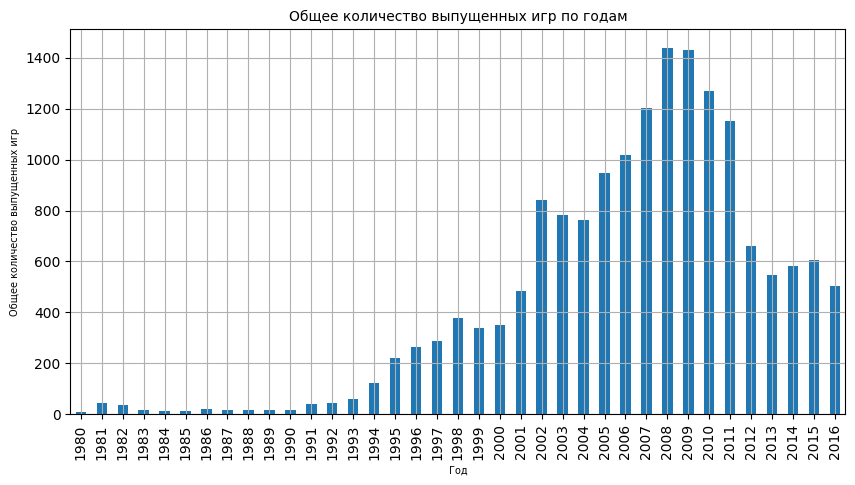

```python
#график количества игр, выпускавшиеся в разные годы
df.groupby(by = 'year_of_release')['name'].count().plot(kind = 'bar', figsize = (10,5), grid = True)
plt.title('Общее количество выпущенных игр по годам', fontsize=10)
plt.xlabel('Год', fontsize=7)
plt.ylabel('Общее количество выпущенных игр', fontsize=7)
plt.show;
```

Пиковые значения выпуска игр пришлись на 2006-2011 гг, после чего произошел спад. С развитием игровой индустрии игры становятся более реалистичными, масштабными и, тем самым, более сложными и трудоемкими для разработки, в связи с чем частота выхода игр уменьшается.

### Изменения продаж по платформам

Для начала рассмотрим продажи по платформам за всех годы, а также оценим жизненный цикл платформ.

```python
#сводная таблица жихненного цикла платформ
pt = df.pivot_table(index = 'platform', values = ['total_sales', 'year_of_release'],
                    aggfunc = {'total_sales': 'sum', 'year_of_release': ['min', 'max']})
#'total_sales' - суммарные продажи по платформе (млн проданных копий), 'max_year' - год последней игры в датасете,
#'min_year' - год первой игры в датасете, будем считать годом выпуска платформы
pt.columns = ['total_sales', 'max_year', 'min_year']
#'lifecycle' - жизненный цикл платформы по данным из датасета
pt['lifecycle'] = pt['max_year'] - pt['min_year'] + 1

pt.sort_values(by = 'total_sales', ascending = False)
```

| platform | total_sales | max_year | min_year | lifecycle |
| --- | --- | --- | --- | --- |
| PS2 | 1245.96 | 2011 | 2000 | 12 |
| X360 | 966.61 | 2016 | 2005 | 12 |
| PS3 | 934.71 | 2016 | 2005 | 12 |
| Wii | 903.31 | 2016 | 2006 | 11 |
| DS | 804.28 | 2013 | 1985 | 29 |
| PS | 727.58 | 2003 | 1994 | 10 |
| PS4 | 314.14 | 2016 | 2013 | 4 |
| GBA | 313.73 | 2007 | 2000 | 8 |
| PSP | 292.77 | 2015 | 2004 | 12 |
| PC | 258.51 | 2016 | 1985 | 32 |
| 3DS | 258.51 | 2016 | 2010 | 7 |
| XB | 254.49 | 2008 | 2000 | 9 |
| GB | 254.43 | 2001 | 1988 | 14 |
| NES | 251.05 | 1994 | 1983 | 12 |
| N64 | 218.48 | 2004 | 1996 | 9 |
| SNES | 200.04 | 1999 | 1990 | 10 |
| GC | 198.59 | 2007 | 2001 | 7 |
| XOne | 159.32 | 2016 | 2013 | 4 |
| 2600 | 86.48 | 1989 | 1980 | 10 |
| WiiU | 82.19 | 2016 | 2012 | 5 |
| PSV | 53.81 | 2016 | 2011 | 6 |
| SAT | 33.59 | 1999 | 1994 | 6 |
| GEN | 28.35 | 1994 | 1990 | 5 |
| DC | 15.95 | 2008 | 1998 | 11 |
| SCD | 1.86 | 1994 | 1993 | 2 |
| NG | 1.44 | 1996 | 1993 | 4 |
| WS | 1.42 | 2001 | 1999 | 3 |
| TG16 | 0.16 | 1995 | 1995 | 1 |
| 3DO | 0.10 | 1995 | 1994 | 2 |
| GG | 0.04 | 1992 | 1992 | 1 |
| PCFX | 0.03 | 1996 | 1996 | 1 |

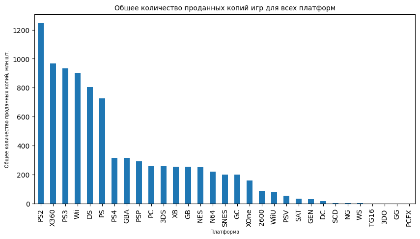

```python
#график количество проданных копий игр для всех платформ
df.groupby(by = 'platform')['total_sales'].sum().sort_values(ascending = False).plot(kind = 'bar', figsize = (10,5))
plt.title('Общее количество проданных копий игр для всех платформ', fontsize=10)
plt.xlabel('Платформа', fontsize=7)
plt.ylabel('Общее количество проданных копий, млн.шт.', fontsize=7)
plt.show;
```

```python
#медианное значение продолжительности жизни платформ
print('Медианное значение продолжительности жизни платформ: ', pt['lifecycle'].median())
```

```
Медианное значение продолжительности жизни платформ:  8.0
```

В сводной таблице есть 2 выдающихся значения: PC (32 года) и DS (29 лет). Т.к. РС является постоянно развивающейся платформой, не привязанной к поколениям других платформ, данные можно считать корректными. Данные по DS требуют проверки корректности.

```python
#проверка корректности данных платформы DS
df.query('platform == "DS"').sort_values(by = 'year_of_release').head(5)
```

|  | name | platform | year_of_release | genre | na_sales | eu_sales | jp_sales | other_sales | critic_score | user_score | rating | total_sales |
| --- | --- | --- | --- | --- | --- | --- | --- | --- | --- | --- | --- | --- |
| 15957 | Strongest Tokyo University Shogi DS | DS | 1985 | Action | 0.00 | 0.00 | 0.02 | 0.00 | NaN | NaN | NA | 0.02 |
| 14161 | Puyo Pop Fever(us sales) | DS | 2004 | Puzzle | 0.03 | 0.00 | 0.00 | 0.00 | NaN | NaN | NA | 0.03 |
| 6578 | Madden NFL 2005 | DS | 2004 | Sports | 0.24 | 0.00 | 0.00 | 0.02 | 68.0 | 7.7 | E | 0.26 |
| 6164 | The Urbz: Sims In the City (US weekly sales) | DS | 2004 | Simulation | 0.26 | 0.00 | 0.00 | 0.02 | NaN | NaN | NA | 0.28 |
| 8465 | Zoo Keeper | DS | 2004 | Puzzle | 0.10 | 0.01 | 0.05 | 0.01 | 74.0 | 7.5 | E | 0.17 |

Год выпуска игры Strongest Tokyo University Shogi DS указан неверно, т.к. год выпуска платформы DS 2004. Исправим ошибку в годе выпуска игры из открытых источников.

```python
#изменение некорректного значения
df.loc[df['name'] == "Strongest Tokyo University Shogi DS", 'year_of_release'] = 2010
```

```python
#определение нового медианного значения продолжительности жизни платформ
pt = df.pivot_table(index = 'platform', values = ['total_sales', 'year_of_release'],
                    aggfunc = {'total_sales': 'sum', 'year_of_release': ['min', 'max']})
pt.columns = ['total_sales', 'max_year', 'min_year']
pt['lifecycle'] = pt['max_year'] - pt['min_year'] + 1
mean_life =  pt['lifecycle'].median()
```

Как видно из сводной таблицы и графика выделяется группа наиболее прибыльных платформ: PS2, X360, PS3, Wii, DS и PS. Построим распределение продаж по годам для этих платформ

```python
#ТОП-6 продаваемых платформ
pt_platform = (df.pivot_table(index = 'platform', values = 'total_sales', aggfunc = 'sum').
               reset_index().
               sort_values(by = 'total_sales', ascending = False).
               head(6)['platform'])
```

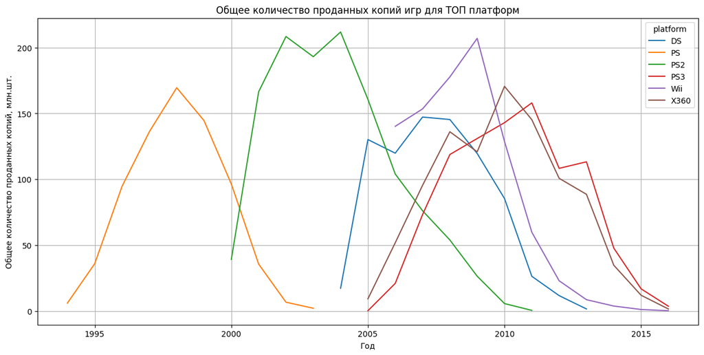

```python
#график продаж ТОП-6 продаваемых платформ
(df.query('platform in @pt_platform')
 .pivot_table(index = ['year_of_release'], columns = ['platform'], values = 'total_sales', aggfunc = 'sum')
 .reset_index()
 .plot(x = 'year_of_release', figsize =(15,7), grid = True)
)
plt.title('Общее количество проданных копий игр для ТОП платформ', fontsize = 12)
plt.xlabel('Год', fontsize = 10)
plt.ylabel('Общее количество проданных копий, млн.шт.', fontsize = 10)
plt.show;
```

Графики продаж напоминают по форме график распределения Пуассона с более длинными хвостами справа. Это говорит о том, что новые платформы быстро набирают популярность, после чего продажи игр идут на спад. Ранее определялся средний срок жизни платформы как 8 лет, однако по графику видно, что для более прибыльных платформ срок жизни больше - примерно 10 лет.

Определим актуальный период для определения потенциально прибыльных продуктов. Поскольку данные за 2016 г неполные, включим в рассмотрение также и 2015 год. Кроме того, для определения общей тенденции по продажам расммотрим дополнительно и 2014 г. Т.о. актуальный период возьмем 2014-2016 гг. И далее будут рассматриваться данные только за этот период.

```python
#выбор актуального периода для определения потенциально прибыльных продуктов
df_act = df[(df['year_of_release'] >= 2014)]
```

### Наиболее прибыльные платформы

Рассмотрим динамику продаж за выбранный период.

```python
#динамика продаж по годам
pt = df_act.pivot_table(index = 'platform', columns = 'year_of_release', values = 'total_sales', aggfunc = 'sum')
pt.columns = ['Y2014','Y2015', 'Y2016']
pt['total'] = pt[['Y2014','Y2015', 'Y2016']].sum(axis = 1)
pt = pt.sort_values(by = 'total', ascending = False)
pt
```

| platform | Y2014 | Y2015 | Y2016 | total |
| --- | --- | --- | --- | --- |
| PS4 | 100.00 | 118.90 | 69.25 | 288.15 |
| XOne | 54.07 | 60.14 | 26.15 | 140.36 |
| 3DS | 43.76 | 27.78 | 15.14 | 86.68 |
| PS3 | 47.76 | 16.82 | 3.60 | 68.18 |
| X360 | 34.74 | 11.96 | 1.52 | 48.22 |
| WiiU | 22.03 | 16.35 | 4.60 | 42.98 |
| PC | 13.28 | 8.52 | 5.25 | 27.05 |
| PSV | 11.90 | 6.25 | 4.25 | 22.40 |
| Wii | 3.75 | 1.14 | 0.18 | 5.07 |
| PSP | 0.24 | 0.12 | NaN | 0.36 |

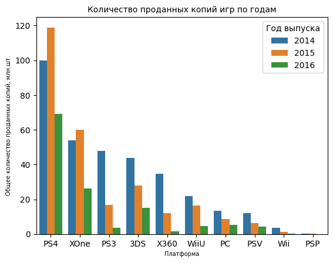

```python
#график динамики продаж по годам
platform_year_sales = df_act.groupby(['platform', 'year_of_release'])['total_sales'].sum().sort_values(ascending = False).reset_index()
sns.barplot(data = platform_year_sales, x = 'platform', y = 'total_sales', hue = 'year_of_release',  ci=None)
plt.title('Количество проданных копий игр по годам', fontsize = 10)
plt.xlabel('Платформа', fontsize = 7)
plt.ylabel('Общее количество проданных копий, млн.шт.', fontsize = 7)
plt.legend(title = 'Год выпуска', loc='upper right')
plt.show;
```

Рассмотрим данные по количеству выпущенных игр для каждой платформы по годам.

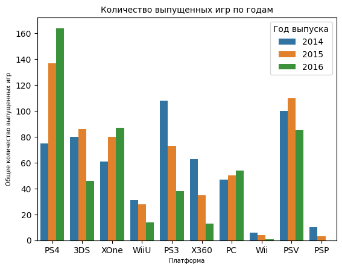

```python
#график динамики выпуска игр по годам
sns.countplot(data = df_act, x = 'platform', hue = 'year_of_release')
plt.title('Количество выпущенных игр по годам', fontsize = 10)
plt.xlabel('Платформа', fontsize = 7)
plt.ylabel('Общее количество выпущенных игр', fontsize = 7)
plt.legend(title = 'Год выпуска', loc='upper right')
plt.show;
```

Т.к. данные за 2016г. могут быть неполными, определим дату выпуска платформы, чтобы определить примерный срок прекращения поддержки платформы по ранее определенному среднему сроку жизни платформ.

```python
#список платформ
pt_platform_act = df_act['platform'].unique()
```

```python
#определение срока жизни платформ
pt = df.query('platform in @pt_platform_act').pivot_table(index = 'platform', values = 'year_of_release', aggfunc = 'min').reset_index().sort_values(by = 'year_of_release', ascending = False)
pt['end_life'] = pt['year_of_release'] + mean_life
pt
```

|  | platform | year_of_release | end_life |
| --- | --- | --- | --- |
| 3 | PS4 | 2013 | 2021.0 |
| 9 | XOne | 2013 | 2021.0 |
| 7 | WiiU | 2012 | 2020.0 |
| 5 | PSV | 2011 | 2019.0 |
| 0 | 3DS | 2010 | 2018.0 |
| 6 | Wii | 2006 | 2014.0 |
| 2 | PS3 | 2005 | 2013.0 |
| 8 | X360 | 2005 | 2013.0 |
| 4 | PSP | 2004 | 2012.0 |
| 1 | PC | 1985 | 1993.0 |

Из полученных данных видно:

1. За 2016 год данные могут быть неполными. Поэтому полностью корректно оценить динамику продаж за 3 года нельзя. Максимальный показатель продаж за 2016 год у PS4, далее следуют XOne, 3DS, PC. Также стоит отметить, что в 2015 году был рост продаж у PS4 и XOne.
2. Опять же учитывая частичность данных за 2016 год, нельзя с полной уверенностью определить динамику выпуска игр. Однако даже на частичных данных видно, что наблюдается рост количества игр на PS4, XOne и PC.
3. При оценке срока прекращения поддержки платформы по ранее определенному средниму сроку жизни платформ, можно предположить, что большинство платформ находят на финальном этапе жизненного цикл. Исключениями являются PS4, XOne, WiiU. А также PC, который не зависит от поколений других платформ и стабильно занимает позиции на рынке игровой индустрии. Определенные сроки конца жизненного цикла PSV и 3DS незначительно больше, чем интересующий для прогнозирования 2017 год, а значит скорее всего будет наблюдаться спад и по выпуску игр, и по продажам.

Таким образом, потенциально наиболее прибыльным можно отнести платформы PS4 и XOne. Кроме того к этому списку можно довабить PC, поскольку это наиболее стабильная платформа, у которой наблюдается рост числа новых игр.

### Диаграмма размаха по глобальным продажам игр в разбивке по платформам

Построим график «ящик с усами» по глобальным продажам игр в разбивке по платформам.

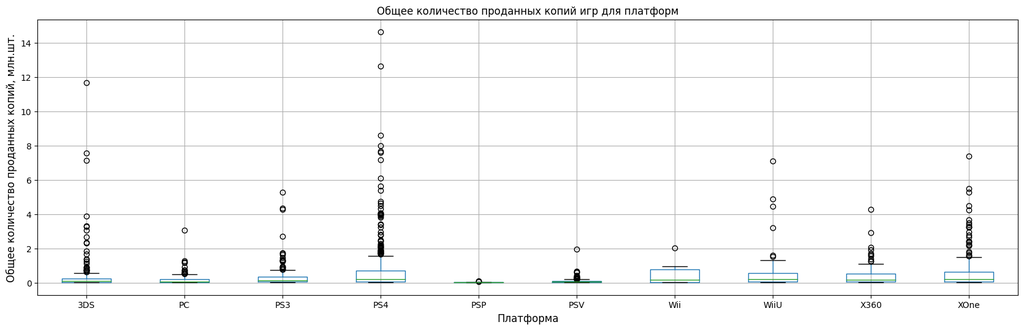

```python
#график «ящик с усами» по глобальным продажам игр в разбивке по платформам
df_act.boxplot(by = 'platform', column = 'total_sales', figsize = (20,6));
plt.suptitle('')
plt.title('Общее количество проданных копий игр для платформ', fontsize = 12)
plt.xlabel('Платформа', fontsize = 12)
plt.ylabel('Общее количество проданных копий, млн.шт.', fontsize = 12)
plt.show;
```

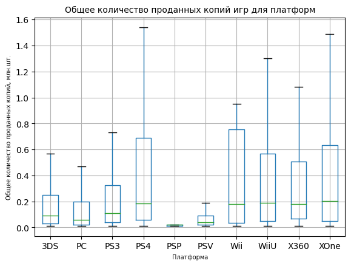

```python
#график «ящик с усами» по глобальным продажам игр в разбивке по платформам без выбросов
df_act.boxplot(by = 'platform', column = 'total_sales', showfliers = False)
plt.suptitle('')
plt.title('Общее количество проданных копий игр для платформ', fontsize = 10)
plt.xlabel('Платформа', fontsize = 7)
plt.ylabel('Общее количество проданных копий, млн.шт.', fontsize = 7)
plt.show;
```

### Влияние отзывов пользователей и критиков на продажи

Рассмотрим влияние отзывов критиков и пользователей на продажи наиболее прибыльной платформы PS4. Для этого построим диаграммы рассеяния и определим коэффициенты корреляции.

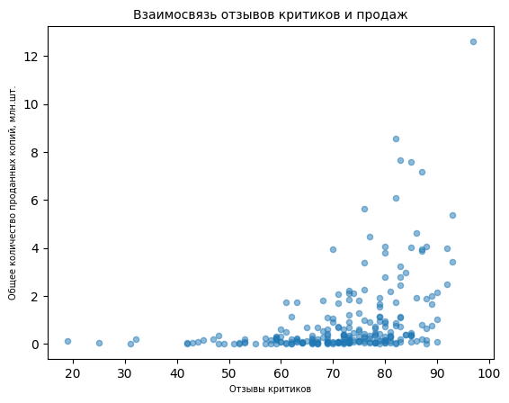

```python
#диаграмма рассеяния, отображающая взаимосвязь отзывов критиков и продаж
df_act[(df_act['platform'] == 'PS4') & (df_act['critic_score'].notnull())].plot(kind = 'scatter', y = 'total_sales', x = 'critic_score', alpha = 0.5)
plt.title('Взаимосвязь отзывов критиков и продаж', fontsize = 10)
plt.xlabel('Отзывы критиков', fontsize = 7)
plt.ylabel('Общее количество проданных копий, млн.шт.', fontsize = 7)
plt.show;
```

```python
#коэффициент корреляции отзывов критиков и продаж
print('Коэффициент корреляции отзывов критиков и продаж:', round(df_act[(df_act['platform'] == 'PS4') & (df_act['critic_score'].notnull())]['critic_score'].corr(df_act[(df_act['platform'] == 'PS4') & (df_act['critic_score'].notnull())]['total_sales']),3))
```

```
Коэффициент корреляции отзывов критиков и продаж: 0.403
```

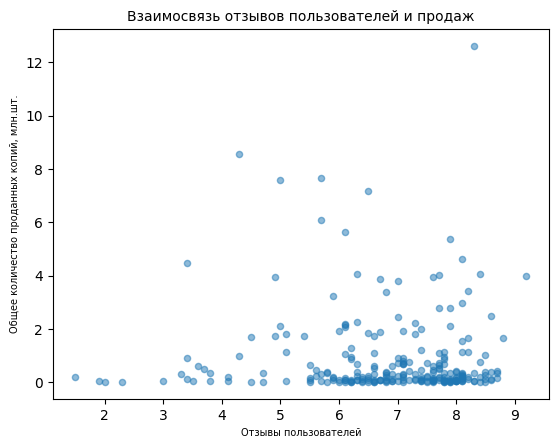

```python
#диаграмма рассеяния, отображающая взаимосвязь отзывов пользователей и продаж
df_act[(df_act['platform'] == 'PS4') & (df_act['user_score'].notnull())].plot(kind = 'scatter', y = 'total_sales', x = 'user_score', alpha = 0.5)
plt.title('Взаимосвязь отзывов пользователей и продаж', fontsize = 10)
plt.xlabel('Отзывы пользователей', fontsize = 7)
plt.ylabel('Общее количество проданных копий, млн.шт.', fontsize = 7)
plt.show;
```

```python
#коэффициент корреляции отзывов пользователей и продаж
print('Коэффициент корреляции отзывов пользователей и продаж:', round(df_act[(df_act['platform'] == 'PS4') & (df_act['user_score'].notnull())]['user_score'].corr(df_act[(df_act['platform'] == 'PS4') & (df_act['user_score'].notnull())]['total_sales']),3))
```

```
Коэффициент корреляции отзывов пользователей и продаж: -0.04
```

Из графиков видно, что для платформы PS4 есть положительная корреляция отзывов критиков и продаж, т.е. чем лучше отзывы критиков, тем выше продажи, линейной корреляции между отзывами пользователей и продажами нет.

Рассмотрим другие платформы.

```python
#списки платформ с заполненными оценками пользователей и критиков
list_platform_critical = []
list_platform_users = []
for item in df_act['platform'].unique():
    if df_act[(df_act['platform'] == item) & (df_act['platform']!= 'PS4')]['critic_score'].sum()!=0:
        list_platform_critical.append(item)
    if df_act[(df_act['platform'] == item) & (df_act['platform']!= 'PS4')]['user_score'].sum()!=0:
        list_platform_users.append(item)
```

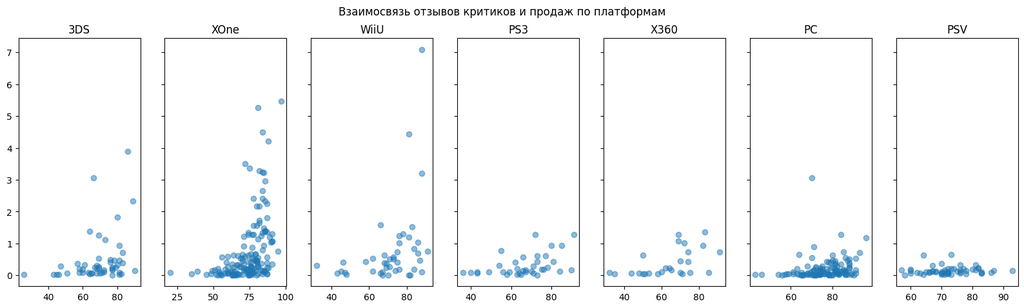

```python
#диаграмма рассеяния, отображающая взаимосвязь отзывов критиков и продаж по платформам
fig, ax = plt.subplots(nrows=1, ncols=len(list_platform_critical), sharey=True, figsize=(20,5))

for i in range(len(list_platform_critical)):
    ax[i].scatter(data = df_act[(df_act['platform'] == list_platform_critical[i]) & (df_act['critic_score'].notnull())], x = 'critic_score', y = 'total_sales',  alpha = 0.5);
    ax[i].set_title(list_platform_critical[i])
fig.suptitle('Взаимосвязь отзывов критиков и продаж по платформам')
plt.show;
```

```python
#коэффициент корреляции отзывов критиков и продаж
for i in range(len(list_platform_critical)):
    print('Корреляция по', list_platform_critical[i],
          'равна:', round(df_act[(df_act['platform'] == list_platform_critical[i]) & (df_act['critic_score'].notnull())]['critic_score'].corr(df_act[(df_act['platform'] == list_platform_critical[i]) & (df_act['critic_score'].notnull())]['total_sales']),3))
```

```
Корреляция по 3DS равна: 0.314
Корреляция по XOne равна: 0.429
Корреляция по WiiU равна: 0.37
Корреляция по PS3 равна: 0.447
Корреляция по X360 равна: 0.526
Корреляция по PC равна: 0.175
Корреляция по PSV равна: 0.043
```

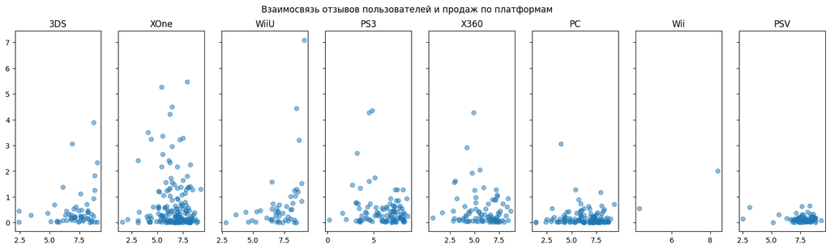

```python
#диаграмма рассеяния, отображающая взаимосвязь отзывов пользователей и продаж по платформам
fig, ax = plt.subplots(nrows=1, ncols=len(list_platform_users), sharey=True, figsize=(20,5))
for i in range(len(list_platform_users)):
    ax[i].scatter(data = df_act[(df_act['platform'] == list_platform_users[i]) & (df_act['user_score'].notnull())], x = 'user_score', y = 'total_sales',  alpha = 0.5);
    ax[i].set_title(list_platform_users[i])
fig.suptitle('Взаимосвязь отзывов пользователей и продаж по платформам')
plt.show();
```

```python
#коэффициент корреляции отзывов пользователей и продаж
for i in range(len(list_platform_users)):
    print('Корреляция по', list_platform_users[i],
          'равна:', round(df_act[(df_act['platform'] == list_platform_users[i]) & (df_act['user_score'].notnull())]['user_score'].corr(df_act[(df_act['platform'] == list_platform_users[i]) & (df_act['user_score'].notnull())]['total_sales']),3))
```

```
Корреляция по 3DS равна: 0.215
Корреляция по XOne равна: -0.07
Корреляция по WiiU равна: 0.408
Корреляция по PS3 равна: -0.167
Корреляция по X360 равна: -0.138
Корреляция по PC равна: -0.072
Корреляция по Wii равна: 1.0
Корреляция по PSV равна: -0.168
```

Из графиков видно, что для всех рассмотренных платформ, кроме PC и PSV, есть положительная корреляция отзывов критиков и продаж. Линейной корреляции между отзывами пользователей и продажами нет, исключением можно назвать WiiU, у которой наблюдается положительная корреляция. Wii с коэффициентом коллеряции не показательна из-за малого числа данных.

### Общее распределение игр по жанрам

Рассмотрим общие продажи и число игр по жанрам.

```python
#сводная таблица с суммой продаж и количеством игр по жанрам
pt = df_act.pivot_table(index = 'genre', values = 'total_sales', aggfunc = ['sum', 'count'])
pt.columns = ['total_sales', 'count_games']
pt = pt.sort_values(by = 'total_sales', ascending = False)
pt
```

| genre | total_sales | count_games |
| --- | --- | --- |
| Action | 199.36 | 619 |
| Shooter | 170.94 | 128 |
| Sports | 109.48 | 161 |
| Role-Playing | 101.44 | 221 |
| Misc | 37.55 | 113 |
| Fighting | 28.22 | 60 |
| Racing | 27.52 | 69 |
| Platform | 18.09 | 38 |
| Adventure | 17.55 | 185 |
| Simulation | 13.13 | 44 |
| Strategy | 3.96 | 37 |
| Puzzle | 2.21 | 14 |

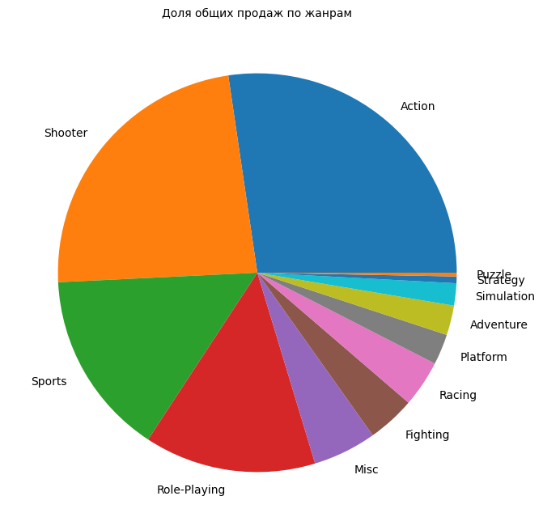

```python
#круговая диаграмма общих продаж по жанрам
pt.plot(kind = 'pie', y = 'total_sales', figsize = (8,8), legend = False, label = '')
plt.title('Доля общих продаж по жанрам', fontsize = 10)
plt.show;
```

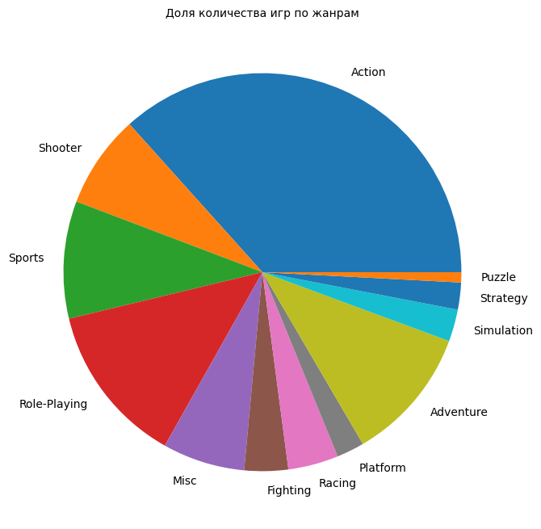

```python
#круговая диаграмма количества по жанрам
pt.plot(kind = 'pie', y = 'count_games', figsize = (8,8), legend = False, label = '')
plt.title('Доля количества игр по жанрам', fontsize = 10)
plt.show;
```

Большую часть рынка занимают игры жанра Action, Shooter и Sports. Больше всего было выпущено Action, Role-Playing и Adventure игр.

Для оценки наиболее и наименее продаваемых жанров найдем медианнные значения продаж.

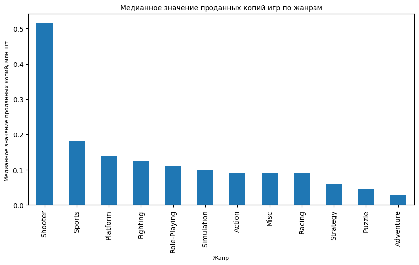

```python
#график медианного значения проданных копий игр по жанрам
df_act.groupby(by = 'genre')['total_sales'].median().sort_values(ascending = False).plot(kind = 'bar', figsize = (10,5))
plt.title('Медианное значение проданных копий игр по жанрам', fontsize = 10)
plt.xlabel('Жанр', fontsize = 8)
plt.ylabel('Медианное значение проданных копий, млн.шт.', fontsize = 8)
plt.show;
```

Явным лидером продаж являются игры жанра Shooter, далее следуют Sports и Platform.

Самыми неприбыльными жанрами являются Adventure, Puzzle и Strategy.

**Вывод**

1. Была построена гистограмма, отображающая количество игр в разные годы. Пиковые значения выпуска игр пришлись на 2006-2011 гг, после чего произошел спад. С развитием технологий игры становятся более сложными для разработки, поэтому частота выхода игр уменьшается.
2. Была построена сводная таблица и гистограмма продаж по всем платформам. По ним выделяется группа наиболее прибыльных платформ: PS2, X360, PS3, Wii, DS и PS. По ним был построен график распределения продаж по годам, который напоминают по форме график распределения Пуассона с более длинными хвостами справа. Это говорит о том, что новые платформы быстро набирают популярность, после чего продажи игр идут на спад. Также был определен средний срок жизни платформы, равный 8 годам.
3. Был выбран актуальный период для определения потенциально прибыльных продуктов на 2017 год. Этот период - 2014-2016 гг.
4. После построения графиков по продажам и количеству игр по каждой платфоре по годам исследуемого периода было выделено 3 потенциально прибыльных платформы: PS4, XOne и РС.
5. По графику размаха видно, что 50% игр на большинстве платформ продаются примерно на одинаковом уровне. Остальные 50% игр продаются большим числом копий на платформах Wii,PS4 и XOne. Наибольшее количество игр бестселлеров на платформах PS4 и 3DS, а самой продаваемой игрой стала игра на платформе PS4.
6. Для всех рассмотренных платформ, кроме PC и PSV, есть положительная корреляция отзывов критиков и продаж. Линейной корреляции между отзывами пользователей и продажами нет, исключением можно назвать WiiU, у которой наблюдается положительная корреляция.
7. Явным лидером продаж являются игры жанра Shooter, далее следуют Sports и Platform; самыми неприбыльными жанрами являются Adventure, Puzzle и Strategy.

## Составление портрета пользователя регионов

### Самые популярные платформы (топ-5)

Опредлелим доли продаж по платформам в каждом регионе.

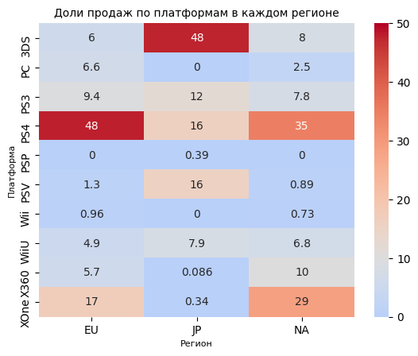

```python
#тепловая карта долей продаж по платформам в каждом регионе
pt = df_act.pivot_table(index = 'platform', values = ['na_sales', 'eu_sales', 'jp_sales'], aggfunc = 'sum')
pt.columns = ['eu_sales', 'jp_sales', 'na_sales']

pt['EU'] = pt['eu_sales']/pt['eu_sales'].sum()*100
pt['JP'] = pt['jp_sales']/pt['jp_sales'].sum()*100
pt['NA'] = pt['na_sales']/pt['na_sales'].sum()*100

pt = pt[['EU','JP','NA']]

sns.heatmap(pt, annot=True, cmap="coolwarm", center = 10, vmax = 50)
plt.title('Доли продаж по платформам в каждом регионе', fontsize = 10)
plt.xlabel('Регион', fontsize = 8)
plt.ylabel('Платформа', fontsize = 8)
plt.show;
```

Самые популярные платформы (топ-5).

EU: PS4, XOne, PS3, PC, 3DS

JP: 3DS, PSV, PS4, PS3, WiiU

NA: PS4, XOne, X360, 3DS, PS3

В общем предпочтения американцев и европейцев схожи. Однако можно заметить, что значение доле продаж игра на PS4 и XOne у американцев близки, на 3 месте идет X360. Это объяснимо: XBox - американская приставка. Японцы предпочитают приставки японского производства. У европейцев несмотря на явное лидерство PS4, в рейтинг популярных платформ присутствует и американский XBox, и PC.

### Самые популярные жанры (топ-5).

Опредлелим доли продаж по жанрам в каждом регионе.

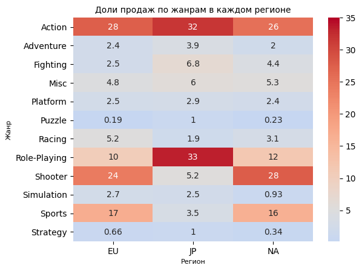

```python
#тепловая карта долей продаж по жанрам в каждом регионе
pt = df_act.pivot_table(index = 'genre', values = ['na_sales', 'eu_sales', 'jp_sales'], aggfunc = 'sum')
pt.columns = ['eu_sales', 'jp_sales', 'na_sales']

pt['EU'] = pt['eu_sales']/pt['eu_sales'].sum()*100
pt['JP'] = pt['jp_sales']/pt['jp_sales'].sum()*100
pt['NA'] = pt['na_sales']/pt['na_sales'].sum()*100

pt = pt[['EU','JP','NA']]

sns.heatmap(pt, annot=True, cmap="coolwarm", center = 5, vmax = 35)
plt.title('Доли продаж по жанрам в каждом регионе', fontsize = 10)
plt.xlabel('Регион', fontsize = 8)
plt.ylabel('Жанр', fontsize = 8)
plt.show;
```

Самые популярные жанры (топ-5).

EU: Action, Shooter, Sports, Role-Playing, Racing

JP: Role-Playing, Action, Fighting, Misc, Shooter

NA: Shooter, Action, Sports, Role-Playing, Misc

В общем предпочтения американцев и европейцев схожи. С небольшой разницей явными лидерами у них стали Action и Shooter, которые составляют около 50% всех продаж, далее Sports и Role-Playing также с минимальной разницей. Последнее место в Топ-5 жанров отличается (у американце Misc, у европейцев Racing), но разница в долях этих жанров достаточна мала. Японцы предпочитают Role-Playing и Action, эти жанры занимают 65% рынка. Далее с минимальными разницами между собой и огромной разницей с лидерами идут Fighting, Misc, Shooter.

### Влияение рейтинга ESRB на продажи в регионах

Определим доли продаж по рейтингам в каждом регионе.

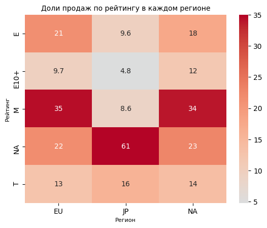

```python
#тепловая карта долей продаж по рейтингам в каждом регионе
pt = df_act.pivot_table(index = 'rating', values = ['na_sales', 'eu_sales', 'jp_sales'], aggfunc = 'sum')
pt.columns = ['eu_sales', 'jp_sales', 'na_sales']

pt['EU'] = pt['eu_sales']/pt['eu_sales'].sum()*100
pt['JP'] = pt['jp_sales']/pt['jp_sales'].sum()*100
pt['NA'] = pt['na_sales']/pt['na_sales'].sum()*100

pt = pt[['EU','JP','NA']]

sns.heatmap(pt, annot=True, cmap="coolwarm", center = 5, vmax = 35)
plt.title('Доли продаж по рейтингу в каждом регионе', fontsize = 10)
plt.xlabel('Регион', fontsize = 8)
plt.ylabel('Рейтинг', fontsize = 8)
plt.show;
```

Треть рынка игр американцев и европейцев - игры с рейтингов М, т.е. для взрослый, что ожидаемо ведь явными лидерами продаж являются шутер и экшен-игры. Пятая часть игр имеет рейтинг Е, что также объяснимо предпочтениями по жанру (Sport, Role-Playing, Misc/Racing)

У японцев выделяется игры с пропусками в рейтинге. Во-первых, это может быть связано с неполнотой данных, а во-вторых, с тем, что в Японии существует свой рейтинг для игр, поэтому для японских игр данных по американскому рейтингу ESRB может просто не быть. Поэтому оценить влияние рейтинга на предпочтения жителей этого региона не получится.

**Вывод**

Европейский и американский рынок игр схож. Кардинально от них отличается Япония.

Самые популярные платформы (топ-5):

- EU: PS4, XOne, PS3, PC, 3DS
- JP: 3DS, PSV, PS4, PS3, WiiU
- NA: PS4, XOne, X360, 3DS, PS3

Самые популярные жанры (топ-5).

- EU: Action, Shooter, Sports, Role-Playing, Racing
- JP: Role-Playing, Action, Fighting, Misc, Shooter
- NA: Shooter, Action, Sports, Role-Playing, Misc

Большинство игр в Северной Америке и Европе имеют рейтинг М, т.е. для взрослый, что ожидаемо ведь явными лидерами продаж являются шутер и экшен-игры. Пятая часть игр имеет рейтинг Е, что также объяснимо предпочтениями по жанру (Sport, Role-Playing, Misc/Racing). У японцев выделяется игры с пропусками в рейтинге. Поэтому оценить влияние рейтинга на предпочтения жителей этого региона не получится.

## Проверка гипотез

Нулевая гипотеза H0 формулируется с использованием знака равенства. Поэтому обе нулевые гипотезы будут сформулированы, как равенство средних, а альтернативные - не равенство.

Выборки являются независимыми, поэтому используется метод ttest_ind.

Уровень статистический значимости установим 1%.

### Средние пользовательские рейтинги платформ Xbox One и PC одинаковые

H0: Средний пользовательский рейтинг платформ Xbox One равен среднему пользовательскому рейтингу PC

H1: Средний пользовательский рейтинг платформ Xbox One не равен среднему пользовательскому рейтингу PC

```python
alpha = 0.01

results = st.ttest_ind(df_act.query('platform == "XOne" & user_score.notnull()')['user_score'],
                       df_act.query('platform == "PC" & user_score.notnull()')['user_score'])

if results.pvalue < alpha:
    print('Отвергаем нулевую гипотезу, p-value =', results.pvalue)
else:
    print('Не получилось отвергнуть нулевую гипотезу, p-value =', results.pvalue)
```

```
Не получилось отвергнуть нулевую гипотезу, p-value = 0.10450507919348415
```

### Средние пользовательские рейтинги жанров Action и Sports разные.

H0: Средние пользовательский рейтинг жанра Action равен среднему пользовательскому рейтингу жанра Sports.

H1: Средние пользовательский рейтинг жанра Action не равен среднему пользовательскому рейтингу жанра Sports.

```python
alpha = 0.01

results = st.ttest_ind(df_act.query('genre == "Action" & user_score.notnull()')['user_score'],
                       df_act.query('genre == "Sports" & user_score.notnull()')['user_score'],
                      equal_var = False)

if results.pvalue < alpha:
    print('Отвергаем нулевую гипотезу, p-value =', results.pvalue)
else:
    print('Не получилось отвергнуть нулевую гипотезу, p-value =', results.pvalue)
```

```
Отвергаем нулевую гипотезу, p-value = 1.1825550382644557e-14
```

**Вывод**

Гипотезу о равенстве средних значений пользовательских рейтингов платформ Xbox One и PC отпровергнуть не удалось. Поэтому принимаем, что она верна.

Гипотеза о равенстве средних значений пользовательских рейтингов жанров Action и Sports была отвергнута, поэтому принимаем альтернативную: средние пользовательские рейтинги жанров Action и Sports разные.

## Вывод

В исследуемом датасете представлены данные о продажах игр, оценки пользователей и экспертов, жанры и платформы за период с 1980 по неполный 2016.

До 1994 г. выпускалось менее 100 игр в год. С 1994г. происходил рост числа новых игр, пиковые значения пришлись на 2006-2011 гг, после чего произошел спад, т.к. с развитием игровой индустрии игры становятся более реалистичными, масштабными и, тем самым, более сложными и трудоемкими для разработки, в связи с чем частота выхода игр уменьшается.

При рассмотрении общего количества проданных копий игр для всех платформ за все время была определена группа наиболее прибыльных платформ: PS2, X360, PS3, Wii, DS и PS.

Новые платформы быстро набирают популярность, после чего продажи игр идут на спад. Средний срок жизни платформы составляет 8 лет, однако для более прибыльных платформ срок жизни больше - примерно 10 лет. Исключением стал PC, который является постоянно развивающейся платформой, не привязанной к поколениям других платформ.

Для определения потенциально популярных продуктов на 2017 г. актуальным периодом были выбраны года с 2014 по 2016.

Для оценки наиболее прибыльных платформ за актуальный период были рассмотрены динамики продаж и выпуска игр, а также рассмотрен период жизненного цикла платформ.

Максимальный показатель продаж за неполный 2016 год у PS4, далее следуют XOne, 3DS, PC. Также стоит отметить, что в 2015 году был рост продаж у PS4 и XOne относительно результатов 2014 г.

По неполным данным за 2016 г. наблюдается рост количества игр на PS4, XOne и PC. Стоит отметить, что кроме этих платформ в 2015 году был рост количества выпускаемых игр на платформах 3DS и PSV, поэтому на конец 2016 года данные по этим платформам могут измениться.

Большинство платформ находятся на финальном этапе жизненного цикл, если рассматривать средний срок жизни платформы 8 лет. Исключениями являются PS4, XOne, WiiU, а также стабильно развивающийся PC. Определенные сроки конца жизненного цикла PSV и 3DS незначительно больше, чем интересующий для прогнозирования 2017 год, а значит, скорее всего, будет наблюдаться спад и по выпуску игр, и по продажам.

Таким образом, к потенциально наиболее прибыльным можно отнести платформы PS4 и XOne. Также к этому списку можно довабить PC, поскольку это наиболее стабильная платформа, у которой наблюдается рост числа новых игр.

Оценка влияния отзывов критиков и пользователей на продажи показала, что для всех рассмотренных платформ, кроме PC и PSV, есть положительная взаимосвязь между отзывами критиков и продажами, т.е. чем выше отзывы критиков, тем больше продажи игры; при этом между отзывами пользователей и продажами линейной взаимосвязи нет, за исключением WiiU, у которой наблюдается положительная корреляция.

Почти половину продаж занимают игры жанра Action и Shooter , далее еще четверть Sports и Role-Playing. По выпуску игр явным лидером является Action - почти 35% всех жанров, еще треть игр имеют жанры Role-Playing, Adventure и Sport.

Оценка медианного значения прибыльности игр по жанрам показала, что наименее прибыльными жанрами стали Adventure, Puzzle и Strategy, а лидером продаж стали игры жанра Shooter, далее следуют Sports и Platform. Однако стоит заметить, что остальные жанры имеют медианные значения близкие между собой и к Sports, и к Platform.

Исследование портрета пользователей регионов показало сходство предпочтений в Северной Америке и Европе, кардинально от них отличаются предпочтения пользователей из Японии.

Так, самыми популярными платформами в Северной Америке и Европе стали PS4 и XOne. Надо отметить, если в Европе 48% предпочитают PS4 и лишь 17% XOne, то в Северной Америке на них приходится 35% и 29% соответственно. На 3 месте в Европе - PS3 (9.4%), а в Северной Америке - Х360 (10%). XBox - американская приставка и суммарно по поколениям ее предпочитают 39% пользователей Северной Америки. В Японии же предпочитают платформы японского производства и портативные платформы: 3DS (48%), PSV и PS4 (по 16%). Продажи игр на XBox в Японии составляют лишь 0,4%. Стоит отметить, что только в Европе продажи игр на PC попали в ТОП-5 и составили 6.6%.

Если рассмотреть региональные продажи игр по жанрам, то тройка самых продаваемых жанров игр у пользователей Европы и Северной Америки - это Action, Shooter и Sports . В лидеры по жанрам в Японии входит Action, практически наравне с которым идет жанр Role-Playing, тройку замыкает Fighting.

Большинство игр в Северной Америке и Европе имеют рейтинг М, т.е. для взрослых, что ожидаемо, так как лидерами продаж являются шутеры и экшен-игры, чаще содержащие насилие, нецензурные выражения и материалы для взрослых, чем другие жанры. Пятая часть игр имеет рейтинг Е, что также объяснимо предпочтениями по жанру (Sport, Role-Playing, Misc/Racing).

У японцев корректно оценить влияние рейтинга ESRB на продажи не является возможным, поскольку в Японии существует свой рейтинг, по которому оцениваются все японские игры, и данных о рейтинге ESRB может не быть.

Таким образом, при определении наиболее потенциально прибыльных продуктов в 2017 г следует рассматривать предпочтения Северной Америки и Европы, поскольку они схожи и занимают большую часть всех продаж. И такими продуктами можно назвать игры на платформы PS4 и XOne жанра Shooter. Также можно рассмотреть игры на PC, поскольку, в отличие от других платформ, эта платформа стабильно развивается и не зависит от поколений. Из жанров можно дополнительно рассмотреть Action, который показывает средние значения прибыльности, однако является самым продаваемым жанром во всем мире.